# Final_R_Analysis

2024-10-25

```r
# Set the CRAN mirror (UK in this case)
options(repos = c(CRAN = "https://cran.ma.imperial.ac.uk/"))
```

## 0: Overview

In this section we will be analysing the reproduction rate of COVID-19 in a number of countries. We will be conducting this analysis through the use of the Random Forest regression model, first taking a look at key indicators, including the Mean Stringency Index, Community Health Index, Government Response Index and Economic Support Index throughout the pandemic.

These collectively capture policy response, temporal progression of the virus and public health conditions, allowing us to take a comprehensive approach to predicting and understanding COVID-19’s reproduction rate. We use mean squared error (MSE) as our performance metric, and in this study we aim to improve a model to be able to capture the complexities of COVID-19 transmission.

## 1: Necessary Imports

```r
#Libraries

library(readxl)
library(ranger)
library(rpart)
library(rpart.plot)
library(partykit)
library(dplyr)
library(Metrics)
library(ggplot2)
library(caret)
```

## 2: Data Access

#### Train Data

```r
#For the author

# Define the path to your data

data_path = "/Users/harrywilson/Desktop/DataScienceToolbox/Assessment-1-Supervised-Prediction/Train_and_Test_data"


# Construct the full file path for the train Excel file

#train_data_path = file.path(data_path, "train.csv")


# Read the Excel/csv file

#train_data = read_excel(train_data_path)

train_data <- read.csv(file.path(data_path, "train.csv"))
```

```r
#For the reader

# Define the path to your data

#data_path = "[replace with your path]"



# Construct the full file path for the train Excel file

#train_data_path = file.path(data_path, "train.xlsx")



# Read the Excel file (using the readxl package)

#train_data = read_excel(train_data_path)
```

#### Test Data

```r
#For the author

# Define the path to your data

data_path = "/Users/harrywilson/Desktop/DataScienceToolbox/Assessment-1-Supervised-Prediction/Train_and_Test_data"



# Construct the full file path for the Excel file

test_data_path = file.path(data_path, "test.xlsx")


# Read the Excel file

test_data = read_excel(test_data_path)

#The mean stringency has a different name to in the training data, so this is going to help us later

# Renaming the column in test_data (if it has the same name)
colnames(test_data)[colnames(test_data) == "mean_stringency...5"] <- "mean_stringency"
```

```r
#For the reader

# Define the path to your data

#data_path = "[replace with your path]"



# Construct the full file path for the Excel file

#test_data_path = file.path(data_path, "test.xlsx")


# Read the Excel file

#test_data = read_excel(test_data_path)
```

```r
head(test_data)
```

```
## # A tibble: 6 × 14
##   date                iso_code continent location Mean_Stringency_Index CH_Index
##   <dttm>              <chr>    <chr>     <chr>                    <dbl>    <dbl>
## 1 2020-03-19 00:00:00 ARE      Asia      United …                  45.4     41.1
## 2 2020-03-20 00:00:00 ARE      Asia      United …                  45.4     41.1
## 3 2020-03-21 00:00:00 ARE      Asia      United …                  45.4     41.1
## 4 2020-03-22 00:00:00 ARE      Asia      United …                  45.4     41.1
## 5 2020-03-23 00:00:00 ARE      Asia      United …                  62.0     54.2
## 6 2020-03-24 00:00:00 ARE      Asia      United …                  62.0     54.2
## # ℹ 8 more variables: Gov_Resp_Index <dbl>, Econ_Sup_Index <dbl>,
## #   days_since <dbl>, total_cases <dbl>, total_deaths <dbl>, new_cases <dbl>,
## #   new_deaths <dbl>, reproduction_rate <dbl>
```

```r
head(train_data)
```

```
##                  date iso_code continent    location Mean_Stringency_Index
## 1 2020-03-29 00:00:00      AFG      Asia Afghanistan                 67.59
## 2 2020-03-30 00:00:00      AFG      Asia Afghanistan                 67.59
## 3 2020-03-31 00:00:00      AFG      Asia Afghanistan                 67.59
## 4 2020-04-01 00:00:00      AFG      Asia Afghanistan                 67.59
## 5 2020-04-02 00:00:00      AFG      Asia Afghanistan                 67.59
## 6 2020-04-03 00:00:00      AFG      Asia Afghanistan                 67.59
##   CH_Index Gov_Resp_Index Econ_Sup_Index days_since total_cases total_deaths
## 1    55.36          48.44              0         84          91            2
## 2    55.36          48.44              0         85          91            2
## 3    55.36          48.44              0         86          91            2
## 4    55.36          48.44              0         87          91            2
## 5    55.36          48.44              0         88          91            2
## 6    55.36          48.44              0         89          91            2
##   new_cases new_deaths reproduction_rate
## 1        67          2              1.51
## 2         0          0              1.51
## 3         0          0              1.52
## 4         0          0              1.51
## 5         0          0              1.51
## 6         0          0              1.50
```

This allows us to check if our data set has been installed correctly, as if it has we should see the first few rows and columns of our data set.

## 3: Implementing the Model

#### Vanilla Model

```r
# Specify the columns for independent variables and dependent variable
independent_vars = train_data[, c("Mean_Stringency_Index", "CH_Index", "Gov_Resp_Index", "Econ_Sup_Index", "days_since")]
dependent_var = train_data$reproduction_rate

# Combine into a new data frame
model_data = data.frame(dependent_var, independent_vars)

# Remove rows with missing values in any of the variables
model_data_complete = na.omit(model_data)

# Fit the random forest model using only complete cases
rf_model <- ranger(
  formula = dependent_var ~ .,    # Use all independent variables
  data = model_data_complete,      # Use the complete dataset
  num.trees = 50,                # Number of trees in the forest
  importance = 'impurity',        # Measure feature importance
  mtry = 2, # Adjust this based on the number of independent variables
  sample.fraction = 0.5,
  num.threads = 3,
  replace = FALSE,
)

# View the model summary
print(rf_model)
```

```
## Ranger result
##
## Call:
##  ranger(formula = dependent_var ~ ., data = model_data_complete,      num.trees = 50, importance = "impurity", mtry = 2, sample.fraction = 0.5,      num.threads = 3, replace = FALSE, )
##
## Type:                             Regression
## Number of trees:                  50
## Sample size:                      134618
## Number of independent variables:  5
## Mtry:                             2
## Target node size:                 5
## Variable importance mode:         impurity
## Splitrule:                        variance
## OOB prediction error (MSE):       0.0123166
## R squared (OOB):                  0.9196815
```

```r
# Specify our independent variables
required_columns <- c("Mean_Stringency_Index", "CH_Index", "Gov_Resp_Index", "Econ_Sup_Index", "days_since")

# Extract the independent variables from test_data
test_independent_vars <- test_data[, required_columns]

# Combine test independent variables and dependent variable into one data frame
test_data_combined <- data.frame(test_independent_vars, reproduction_rate = test_data$reproduction_rate)

# Remove rows with missing values in any of the columns (independent or dependent)
test_data_complete <- na.omit(test_data_combined)

# Separate independent variables and actual values after omitting rows with NAs
test_independent_vars_complete <- test_data_complete[, required_columns]  # Independent variables
actual_values_complete <- test_data_complete$reproduction_rate  # Dependent variable

# Check the number of rows for consistency
cat("Number of rows in independent variables:", nrow(test_independent_vars_complete), "\n")
```

```
## Number of rows in independent variables: 32431
```

```r
cat("Number of rows in actual values:", length(actual_values_complete), "\n")
```

```
## Number of rows in actual values: 32431
```

```r
# Make predictions using the complete test data
predictions <- predict(rf_model, data = test_independent_vars_complete)

# View the predicted values
predicted_values <- predictions$predictions

# Calculate RMSE and MAE to evaluate prediction accuracy
mse <- mse(actual_values_complete, predicted_values)  # MSE calculation using function
mae <- mae(actual_values_complete, predicted_values)  # MAE calculation using function

# Print the error metrics
cat("MSE:", mse, "\n")
```

```
## MSE: 0.1407711
```

```r
cat("MAE:", mae, "\n")
```

```
## MAE: 0.2805596
```

#### Bootstrapping Our Model

```r
# Specify the columns for independent variables and dependent variable
independent_vars = train_data[, c("Mean_Stringency_Index", "CH_Index", "Gov_Resp_Index", "Econ_Sup_Index", "days_since")]
dependent_var = train_data$reproduction_rate

# Combine into a new data frame
model_data = data.frame(dependent_var, independent_vars)

# Remove rows with missing values in any of the variables
model_data_complete = na.omit(model_data)

rf_model_tuned <- ranger(
  formula = dependent_var ~ .,
  data = model_data_complete,
  num.trees = 50,
  importance = 'impurity',
  mtry = 2,
  sample.fraction = 0.5,
  num.threads = 3,
  replace = TRUE,
)


# View the model summary
print(rf_model_tuned)
```

```
## Ranger result
##
## Call:
##  ranger(formula = dependent_var ~ ., data = model_data_complete,      num.trees = 50, importance = "impurity", mtry = 2, sample.fraction = 0.5,      num.threads = 3, replace = TRUE, )
##
## Type:                             Regression
## Number of trees:                  50
## Sample size:                      134618
## Number of independent variables:  5
## Mtry:                             2
## Target node size:                 5
## Variable importance mode:         impurity
## Splitrule:                        variance
## OOB prediction error (MSE):       0.01294685
## R squared (OOB):                  0.9155715
```

```r
required_columns <- c("Mean_Stringency_Index", "CH_Index", "Gov_Resp_Index", "Econ_Sup_Index", "days_since")
# Step 1: Extract the independent variables from test_data
test_independent_vars <- test_data[, required_columns]

# Step 2: Combine test independent variables and dependent variable into one data frame
test_data_combined <- data.frame(test_independent_vars, reproduction_rate = test_data$reproduction_rate)

# Step 3: Remove rows with missing values in any of the columns (independent or dependent)
test_data_complete <- na.omit(test_data_combined)

# Step 4: Separate independent variables and actual values after omitting rows with NAs
test_independent_vars_complete <- test_data_complete[, required_columns]  # Independent variables
actual_values_complete <- test_data_complete$reproduction_rate  # Dependent variable

# Check the number of rows for consistency
cat("Number of rows in independent variables:", nrow(test_independent_vars_complete), "\n")
```

```
## Number of rows in independent variables: 32431
```

```r
cat("Number of rows in actual values:", length(actual_values_complete), "\n")
```

```
## Number of rows in actual values: 32431
```

```r
# Step 5: Make predictions using the complete test data
predictions <- predict(rf_model_tuned, data = test_independent_vars_complete)

# View the predicted values
predicted_values <- predictions$predictions

# Step 6: Calculate RMSE and MAE to evaluate prediction accuracy
mse <- mse(actual_values_complete, predicted_values)  # MSE calculation using function
mae <- mae(actual_values_complete, predicted_values)  # MAE calculation using function

# Print the error metrics
cat("MSE:", mse, "\n")
```

```
## MSE: 0.1417373
```

```r
cat("MAE:", mae, "\n")
```

```
## MAE: 0.2806927
```

#### Changing Independent Variables

To further improve the predictive accuracy of our model, we introduce additional independent variables, looking at total cases and deaths, along with new cases and deaths. These variables offer even more detail on the pandemic’s progression. By expanding the model’s feature set, we enhance its ability to understand COVID-19 transmission dynamics.

```r
# Specify the columns for independent variables and dependent variable
independent_vars = train_data[, c("Mean_Stringency_Index", "CH_Index", "Gov_Resp_Index", "Econ_Sup_Index", "days_since", "total_cases", "total_deaths", "new_cases", "new_deaths")]
dependent_var = train_data$reproduction_rate

# Combine into a new data frame
model_data = data.frame(dependent_var, independent_vars)

# Remove rows with missing values in any of the variables
model_data_complete = na.omit(model_data)

rf_model_tuned <- ranger(
  formula = dependent_var ~ .,    # Use all independent variables
  data = model_data_complete,      # Use the complete dataset
  num.trees = 50,                # Number of trees in the forest
  importance = 'impurity',        # Measure feature importance
  mtry = 2, # Adjust this based on the number of independent variables
  sample.fraction = 0.5,
  num.threads = 3,
  replace = TRUE,
)


# View the model summary
print(rf_model_tuned)
```

```
## Ranger result
##
## Call:
##  ranger(formula = dependent_var ~ ., data = model_data_complete,      num.trees = 50, importance = "impurity", mtry = 2, sample.fraction = 0.5,      num.threads = 3, replace = TRUE, )
##
## Type:                             Regression
## Number of trees:                  50
## Sample size:                      134618
## Number of independent variables:  9
## Mtry:                             2
## Target node size:                 5
## Variable importance mode:         impurity
## Splitrule:                        variance
## OOB prediction error (MSE):       0.006386628
## R squared (OOB):                  0.9583518
```

```r
required_columns <- c("Mean_Stringency_Index", "CH_Index", "Gov_Resp_Index", "Econ_Sup_Index", "days_since", "total_cases", "total_deaths", "new_cases", "new_deaths")
# Step 1: Extract the independent variables from test_data
test_independent_vars <- test_data[, required_columns]

# Step 2: Combine test independent variables and dependent variable into one data frame
test_data_combined <- data.frame(test_independent_vars, reproduction_rate = test_data$reproduction_rate)

# Step 3: Remove rows with missing values in any of the columns (independent or dependent)
test_data_complete <- na.omit(test_data_combined)

# Step 4: Separate independent variables and actual values after omitting rows with NAs
test_independent_vars_complete <- test_data_complete[, required_columns]  # Independent variables
actual_values_complete <- test_data_complete$reproduction_rate  # Dependent variable

# Check the number of rows for consistency
cat("Number of rows in independent variables:", nrow(test_independent_vars_complete), "\n")
```

```
## Number of rows in independent variables: 32431
```

```r
cat("Number of rows in actual values:", length(actual_values_complete), "\n")
```

```
## Number of rows in actual values: 32431
```

```r
# Step 5: Make predictions using the complete test data
predictions <- predict(rf_model_tuned, data = test_independent_vars_complete)

# View the predicted values
predicted_values <- predictions$predictions

# Step 6: Calculate RMSE and MAE to evaluate prediction accuracy
mse <- mse(actual_values_complete, predicted_values)  # MSE calculation using function
mae <- mae(actual_values_complete, predicted_values)  # MAE calculation using function

# Print the error metrics
cat("MSE:", mse, "\n")
```

```
## MSE: 0.1152761
```

```r
cat("MAE:", mae, "\n")
```

```
## MAE: 0.2503611
```

#### Adjusting Hyperparameters

For my final iteration of the model, I used cross-validation to find the optimal number of trees, along with modifying the sample fraction from 0.5 to 1. Overall, these hyperparameter adjustments aim to optimise the model’s ability to predict by enhancing the diversity of the trees, whilst maintaining access to our complete dataset for training.

#### 3 Fold Cross-Validation

```r
# Specify columns for independent and dependent variables
independent_vars <- train_data[, c("Mean_Stringency_Index", "CH_Index", "Gov_Resp_Index",
                                    "Econ_Sup_Index", "days_since", "total_cases",
                                    "total_deaths", "new_cases", "new_deaths")]
dependent_var <- train_data$reproduction_rate

# Combine into a new data frame
model_data <- data.frame(dependent_var, independent_vars)

# Remove rows with missing values
model_data_complete <- na.omit(model_data)

# Set up cross-validation control
train_control <- trainControl(method = "cv", number = 3)  # 3-fold cross-validation

# Define the list of num.trees values to evaluate
num_trees_list <- c(50, 350, 500)

# Initialize a list to store the results
results <- list()

# Loop through each value of num.trees
for (num_trees in num_trees_list) {
  # Train model using cross-validation with the current num.trees value
  rf_model_cv <- train(
    dependent_var ~ .,                 # Use all independent variables
    data = model_data_complete,        # Use complete dataset
    method = "ranger",                 # Use ranger package
    trControl = train_control,         # Apply cross-validation
    tuneGrid = expand.grid(mtry = 2,    # Fix mtry to 2
                           splitrule = "variance",
                           min.node.size = 5),
    importance = "impurity",           # Measure feature importance
    num.trees = num_trees,             # Set current num.trees
    num.threads = 3,                   # Number of threads
    replace = TRUE
  )

  # Calculate MSE for this configuration
  min_mse <- min(rf_model_cv$results$RMSE^2)  # Convert RMSE to MSE

  # Store the model and the best result for this num.trees value
  results[[paste("num_trees", num_trees, sep = "_")]] <- list(
    model = rf_model_cv,
    bestTune = rf_model_cv$bestTune,
    MSE = min_mse  # Store minimum MSE for this configuration
  )
}
# Print results for each num.trees
for (res in names(results)) {
  cat("Results for", res, ":\n")
  print(results[[res]]$bestTune)
  cat("Best MSE:", results[[res]]$MSE, "\n\n")
}
```

```
## Results for num_trees_50 :
##   mtry splitrule min.node.size
## 1    2  variance             5
## Best MSE: 0.006425811
##
## Results for num_trees_350 :
##   mtry splitrule min.node.size
## 1    2  variance             5
## Best MSE: 0.005902757
##
## Results for num_trees_500 :
##   mtry splitrule min.node.size
## 1    2  variance             5
## Best MSE: 0.005942508
```

```r
# Select the model with the lowest MSE
best_model_key <- names(results)[which.min(sapply(results, function(x) x$MSE))]
best_model <- results[[best_model_key]]$model

# Print best model's parameters
cat("Best model parameters (lowest MSE):\n")
```

```
## Best model parameters (lowest MSE):
```

```r
print(best_model$bestTune)
```

```
##   mtry splitrule min.node.size
## 1    2  variance             5
```

```r
cat("Number of trees:", gsub("num_trees_", "", best_model_key), "\n")
```

```
## Number of trees: 350
```

```r
cat("Best cross-validated MSE:", min(sapply(results, function(x) x$MSE)), "\n\n")
```

```
## Best cross-validated MSE: 0.005902757
```

```r
# Make predictions using the best model
predictions <- predict(best_model, newdata = test_independent_vars_complete)

# Calculate performance metrics on test data
mse <- mean((actual_values_complete - predictions)^2)  # Calculate MSE
mae <- mean(abs(actual_values_complete - predictions))  # Calculate MAE

# Print error metrics
cat("Test MSE:", mse, "\n")
```

```
## Test MSE: 0.1142778
```

```r
cat("Test MAE:", mae, "\n")
```

```
## Test MAE: 0.2499384
```

##### Understanding Our Hyperparameters

Adjusting “num.trees = 50” to “num.trees = 350” increases the number of decision trees in our forest. This should improve performance by reducing variane, and enhancing stability in our model.

We kept “mtry = 2”, which means the model selects two independent variables at random to consider at each split. this introduces randomness into our model, and helps to prevent overfitting.

Changing “sample.fraction” to 1 means the model uses the entire dataset for training at each tree. However, setting “sample.fraction = 0.5” means only half the dataset is used at each tree. This is advantageous to ensuring all data contributes to our model.

```r
# Specify the columns for independent variables and dependent variable
independent_vars = train_data[, c("Mean_Stringency_Index", "CH_Index", "Gov_Resp_Index", "Econ_Sup_Index", "days_since", "total_cases", "total_deaths", "new_cases", "new_deaths")]
dependent_var = train_data$reproduction_rate

# Combine into a new data frame
model_data = data.frame(dependent_var, independent_vars)

# Remove rows with missing values in any of the variables
model_data_complete = na.omit(model_data)

rf_model_tuned <- ranger(
  formula = dependent_var ~ .,    # Use all independent variables
  data = model_data_complete,      # Use the complete dataset
  num.trees = 350,                # Number of trees in the forest
  importance = 'impurity',        # Measure feature importance
  mtry = 2, # Adjust this based on the number of independent variables
  sample.fraction = 1,
  num.threads = 3,
  replace = TRUE
)
# View the model summary
print(rf_model_tuned)
```

```
## Ranger result
##
## Call:
##  ranger(formula = dependent_var ~ ., data = model_data_complete,      num.trees = 350, importance = "impurity", mtry = 2, sample.fraction = 1,      num.threads = 3, replace = TRUE)
##
## Type:                             Regression
## Number of trees:                  350
## Sample size:                      134618
## Number of independent variables:  9
## Mtry:                             2
## Target node size:                 5
## Variable importance mode:         impurity
## Splitrule:                        variance
## OOB prediction error (MSE):       0.00424043
## R squared (OOB):                  0.9723475
```

```r
required_columns <- c("Mean_Stringency_Index", "CH_Index", "Gov_Resp_Index", "Econ_Sup_Index", "days_since", "total_cases", "total_deaths", "new_cases", "new_deaths")
# Step 1: Extract the independent variables from test_data
test_independent_vars <- test_data[, required_columns]

# Step 2: Combine test independent variables and dependent variable into one data frame
test_data_combined <- data.frame(test_independent_vars, reproduction_rate = test_data$reproduction_rate)

# Step 3: Remove rows with missing values in any of the columns (independent or dependent)
test_data_complete <- na.omit(test_data_combined)

# Step 4: Separate independent variables and actual values after omitting rows with NAs
test_independent_vars_complete <- test_data_complete[, required_columns]  # Independent variables
actual_values_complete <- test_data_complete$reproduction_rate  # Dependent variable

# Check the number of rows for consistency
cat("Number of rows in independent variables:", nrow(test_independent_vars_complete), "\n")
```

```
## Number of rows in independent variables: 32431
```

```r
cat("Number of rows in actual values:", length(actual_values_complete), "\n")
```

```
## Number of rows in actual values: 32431
```

```r
# Step 5: Make predictions using the complete test data
predictions <- predict(rf_model_tuned, data = test_independent_vars_complete)

# View the predicted values
predicted_values <- predictions$predictions

# Step 6: Calculate RMSE and MAE to evaluate prediction accuracy
mse <- mse(actual_values_complete, predicted_values)  # MSE calculation using function
mae <- mae(actual_values_complete, predicted_values)  # MAE calculation using function

# Print the error metrics
cat("MSE:", mse, "\n")
```

```
## MSE: 0.1142107
```

```r
cat("MAE:", mae, "\n")
```

```
## MAE: 0.2502123
```

#### Visualising Our Random Forest

As we have a Random Forest with 350 trees, it’s very computationally expensive to plot the whole thing, along with being more complex to understand. Instead, we choose to plot a segment of the data.

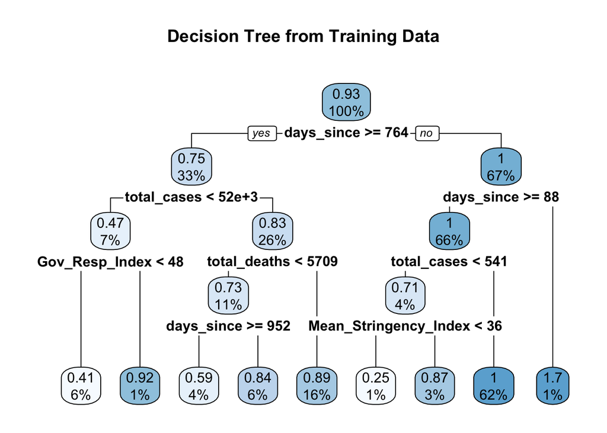

```r
# Fit a decision tree model
dt_model <- rpart(dependent_var ~ Mean_Stringency_Index + CH_Index + Gov_Resp_Index + Econ_Sup_Index + days_since + total_cases + total_deaths + new_cases + new_deaths, data = model_data_complete)

# Plot the decision tree
rpart.plot(dt_model, main = "Decision Tree from Training Data")
```

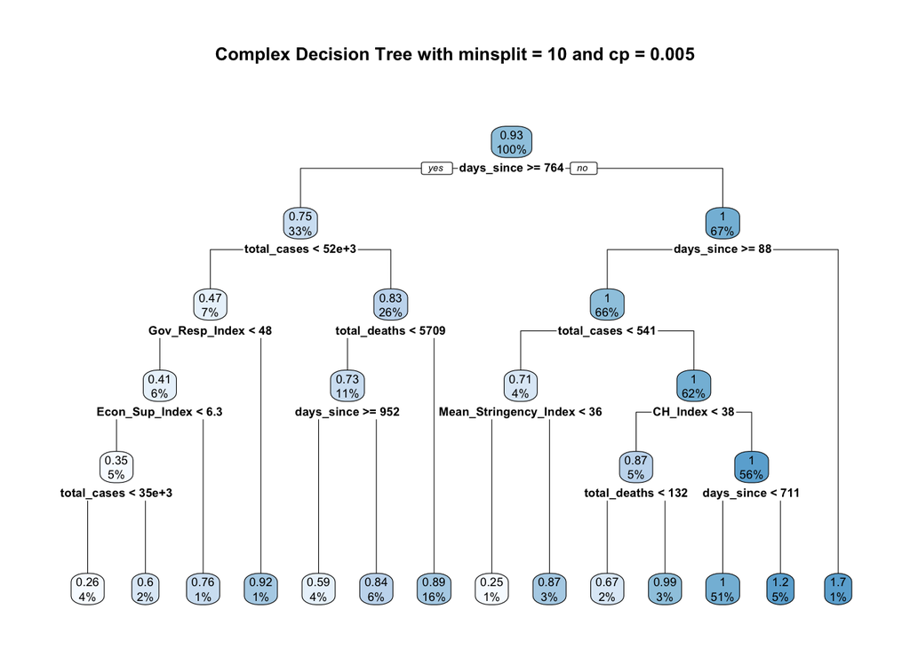

```r
dt_model_3 <- rpart(
  dependent_var ~ Mean_Stringency_Index + CH_Index + Gov_Resp_Index + Econ_Sup_Index + days_since + total_cases + total_deaths + new_cases + new_deaths,
  data = model_data_complete,
  control = rpart.control(minsplit = 10, cp = 0.005)
)
rpart.plot(dt_model_3, main = "Complex Decision Tree with minsplit = 10 and cp = 0.005")
```

## 4: Visualising Model Success

#### Scatter Plot Visualising Actual Reproduction Rates vs. Our Predicted Rates for all Countries

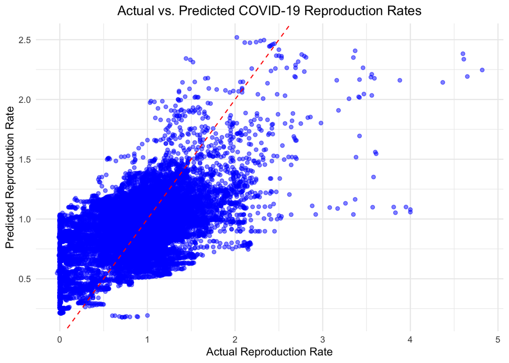

```r
# Step 1: Extract the independent variables and dependent variable (reproduction rate)
test_data_combined <- data.frame(
  test_data[, required_columns],  # Independent variables
  reproduction_rate = test_data$reproduction_rate  # Dependent variable
)

# Step 2: Remove rows with missing values across all required columns
test_data_complete <- na.omit(test_data_combined)

# Step 3: Separate independent variables and actual values after removing NAs
test_independent_vars_complete <- test_data_complete[, required_columns]
actual_values_complete <- test_data_complete$reproduction_rate

# Step 4: Make predictions using the complete test data
predictions <- predict(rf_model_tuned, data = test_independent_vars_complete)
predicted_values <- predictions$predictions

# Step 5: Create a data frame with actual and predicted values for plotting
results <- data.frame(
  actual_reproduction_rate = actual_values_complete,
  predicted_reproduction_rate = predicted_values
)

# Step 6: Plot actual vs. predicted reproduction rates
library(ggplot2)
ggplot(results, aes(x = actual_reproduction_rate, y = predicted_reproduction_rate)) +
  geom_point(alpha = 0.5, color = "blue") +
  geom_abline(slope = 1, intercept = 0, linetype = "dashed", color = "red") +  # 1:1 line for reference
  labs(
    title = "Actual vs. Predicted COVID-19 Reproduction Rates",
    x = "Actual Reproduction Rate",
    y = "Predicted Reproduction Rate"
  ) +
  theme_minimal() +
  theme(plot.title = element_text(hjust = 0.5))
```

This is a scatter plot of actual reproduction rate against the random forests prediction. Better performing models will have a higher correlation with the red line, so it is evident our model is making errors.

#### Scatter Plot of Our Residuals

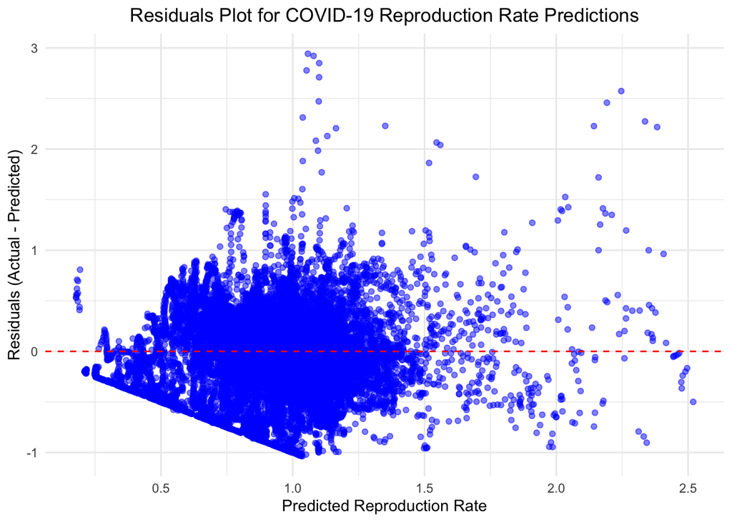

```r
# Step 1: Calculate residuals
results <- data.frame(
  actual_reproduction_rate = actual_values_complete,
  predicted_reproduction_rate = predicted_values
)
results$residuals <- results$actual_reproduction_rate - results$predicted_reproduction_rate

# Step 2: Plot residuals against predicted reproduction rates
ggplot(results, aes(x = predicted_reproduction_rate, y = residuals)) +
  geom_point(alpha = 0.5, color = "blue") +
  geom_hline(yintercept = 0, linetype = "dashed", color = "red") +  # Reference line at zero
  labs(
    title = "Residuals Plot for COVID-19 Reproduction Rate Predictions",
    x = "Predicted Reproduction Rate",
    y = "Residuals (Actual - Predicted)"
  ) +
  theme_minimal() +
  theme(plot.title = element_text(hjust = 0.5))
```

This residuals plot shows the residuals, the difference between actual and predicted values, on the y-axis against predicted values of reproduction rate on the x-axis. A great model would have most points by the red line.